# Unit 9 Assignment

Steve Bramhall

October 26, 2018

### A. Clean and prepare the data

#### 1. First read the two data sets into data frames beerDF and breweryDF from csv files. The columns (variables) of each data frame were custom named to be more readable and to provide a handle to merge the data.Create column for Brewery ID that is common to both datasets.

```r
# Read beer data from csv file and put into breweryDF data frame.Then rename columns to be more readable.
beerDF <- read.csv(".\\InputFiles\\Beers.csv",header=TRUE,sep=",",stringsAsFactors = TRUE, encoding = "UTF-8")
names(beerDF) <- c("BeerName","BeerID","AlcoholByVolume","BitternessUnits","BreweryID",
                   "BeerStyle","Ounces") # rename table columns

# Read brewery data from csv file and put into breweryDF data frame.Then rename columns to be more readable.
breweryDF <- read.csv(".\\InputFiles\\Breweries.csv",header=TRUE,sep=",",stringsAsFactors = FALSE)
names(breweryDF) <- c("BreweryID","BreweryName","City","State") # rename table columns
```

#### 2. Merge the beer and brewery data sets into a sigle dataframe.

```r
#Merge brewery and beer data into the brewDataDF data frame
allBeerDataDF <- merge.data.frame(breweryDF,beerDF,by="BreweryID")
```

#### 3. Remove surrounding whitespace for State info

```r
allBeerDataDF$State <- sapply(allBeerDataDF$State, str_trim)    # remove surrounding whitespace to state col
```

#### 4. Create a separate data set with only CO & TX beer and remove IBU’s with NA’s.

```r
beerCOTX=subset(allBeerDataDF,(allBeerDataDF$State=="CO" | allBeerDataDF$State=="TX") & !is.na(BitternessUnits))
```

#### 5. Order beerCOTX by IBU (ascending)

```r
beerCOTX <- beerCOTX[with(beerCOTX,order(BitternessUnits)),] # sort by IBU, ascending
```

### B. Create initial plots of the data

#### 6. Plot Colorado Beers’ ABV vs IBU

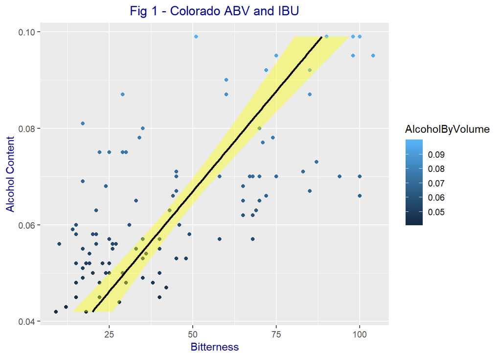

```r
scatterplot <- ggplot(data=filter(beerCOTX,State=="CO"), aes(AlcoholByVolume,BitternessUnits,col=AlcoholByVolume)) +
  geom_point() + coord_flip() +                                                             # make horizontal scatter plot
  ggtitle("Fig 1 - Colorado ABV and IBU") +                                                 # add title
  theme(plot.title = element_text(color="dark blue",hjust=0.5)) +                           # format main title
  xlab("Alcohol Content") +  ylab("Bitterness") +                                           # add axis labels
  theme(axis.title.x = element_text(color="dark blue")) +                                   # format x title
  theme(axis.title.y = element_text(color="dark blue"))                                     # format y title

#linear fit by lm to scatterplot
scatterplot+geom_smooth(method = "lm", colour = "black", fill="yellow")
```

#### 6. Plot Texas Beers’ ABV vs IBU

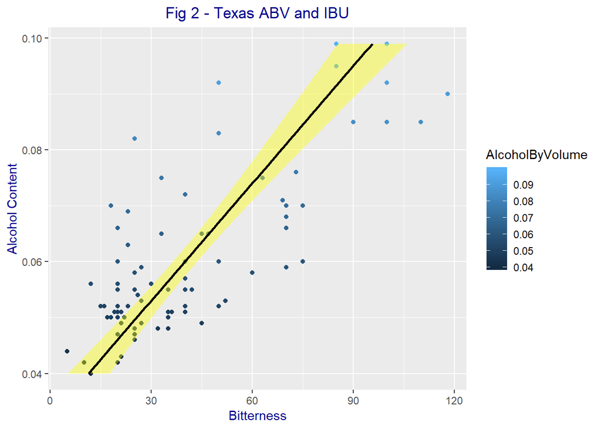

```r
scatterplot <- ggplot(data=filter(beerCOTX,State=="TX"), aes(AlcoholByVolume,BitternessUnits,col=AlcoholByVolume)) +
  geom_point() + coord_flip() +                                                             # make horizontal scatter plot
  ggtitle("Fig 2 - Texas ABV and IBU") +                                                    # add title
  theme(plot.title = element_text(color="dark blue",hjust=0.5)) +                           # format main title
  xlab("Alcohol Content") +  ylab("Bitterness") +                                           # add axis labels
  theme(axis.title.x = element_text(color="dark blue")) +                                   # format x title
  theme(axis.title.y = element_text(color="dark blue"))                                     # format y title

#linear fit by lm to scatterplot
scatterplot+geom_smooth(method = "lm", colour = "black", fill="yellow")
```

### C. Model the data

#### 7. Plot data, add linear model, check assumptions

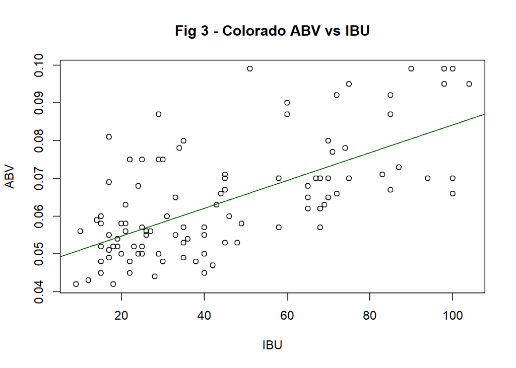

```r
# creating subset for CO, easier to work with
beerCO=subset(beerCOTX,beerCOTX$State=="CO")

fitCO <- lm(AlcoholByVolume~BitternessUnits,data=beerCO) # linear model
plot(beerCO$AlcoholByVolume~beerCO$BitternessUnits,      # scatter plot for CO
     main="Fig 3 - Colorado ABV vs IBU",                 # add plot title
     xlab="IBU",                                         # add x-axis label
     ylab="ABV")                                         # add y-axis label
abline(fitCO,col='dark green')                           # add linear fit line
```

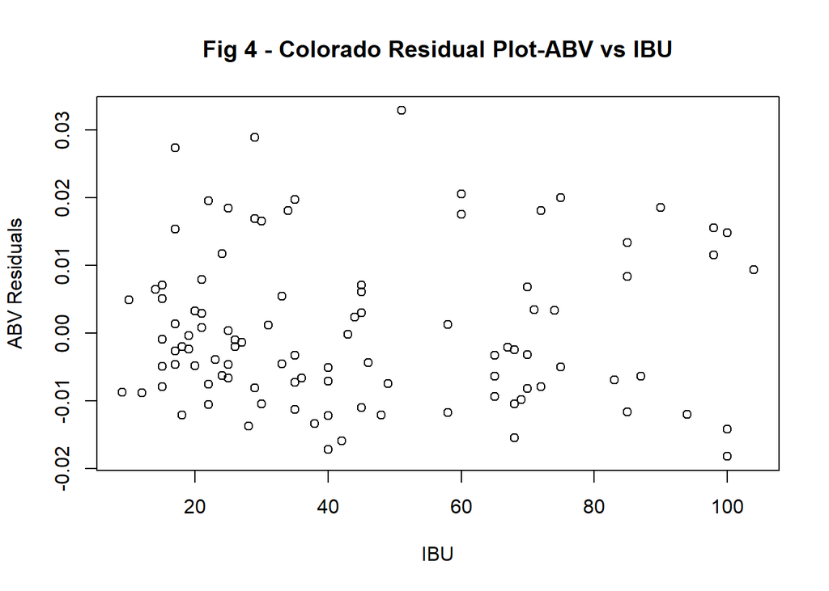

```r
residsCO=resid(fitCO)                                    # residuals for CO
plot(beerCO$BitternessUnits,residsCO,                    # plot CO residuals
     main="Fig 4 - Colorado Residual Plot-ABV vs IBU",   # add plot title
     xlab="IBU",                                         # add x-axis label
     ylab="ABV Residuals")                               # add y-axis label
```

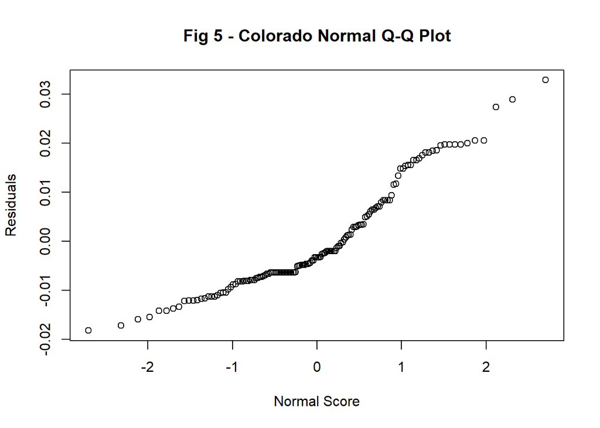

```r
qqnorm(residsCO,main="Fig 5 - Colorado Normal Q-Q Plot", # QQ Plot for CO residuals
       xlab="Normal Score",                              # add y-axis label
       ylab="Residuals")                                 # add x-axis label
```

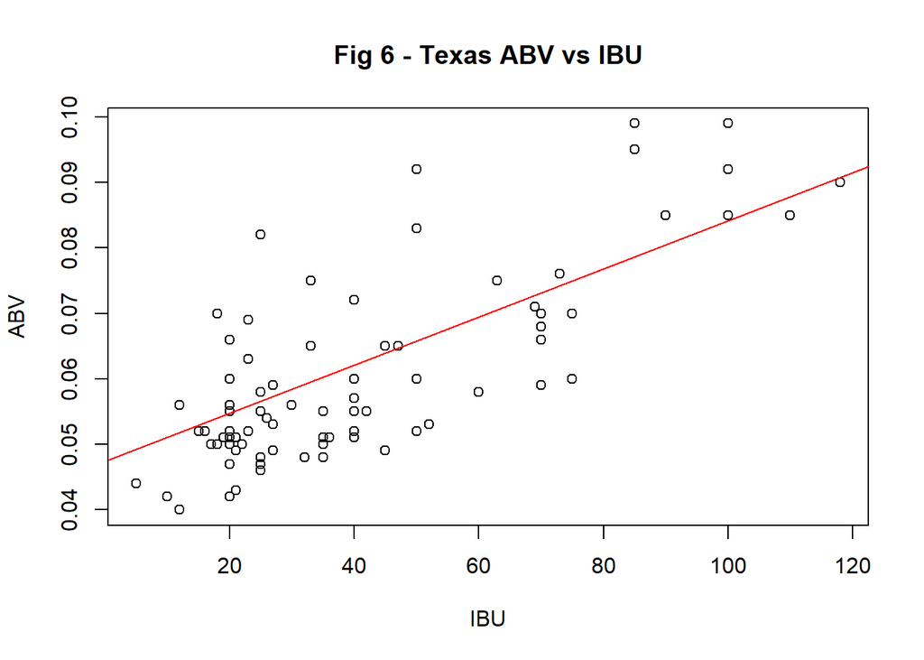

```r
# creating subset for TX, easier to work with
beerTX=subset(beerCOTX,beerCOTX$State=="TX")

fitTX <- lm(AlcoholByVolume~BitternessUnits,data=beerTX) # linear model
plot(beerTX$AlcoholByVolume~beerTX$BitternessUnits,      # scatter plot for TX
     main="Fig 6 - Texas ABV vs IBU",                    # add plot title
     xlab="IBU",                                         # add x-axis label
     ylab="ABV")                                         # add y-axis label
abline(fitCO,col='red')                                  # add linear fit line
```

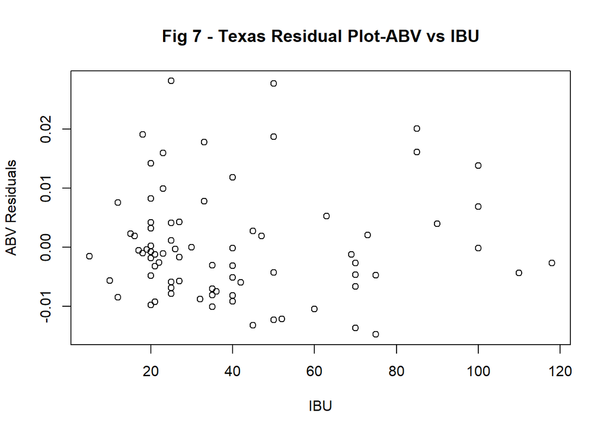

```r
residsTX=resid(fitTX)                                    # residuals for TX
plot(beerTX$BitternessUnits,residsTX,                    # plot TX residuals
     main="Fig 7 - Texas Residual Plot-ABV vs IBU",      # add plot title
     xlab="IBU",                                         # add x-axis label
     ylab="ABV Residuals")                               # add y-axis label
```

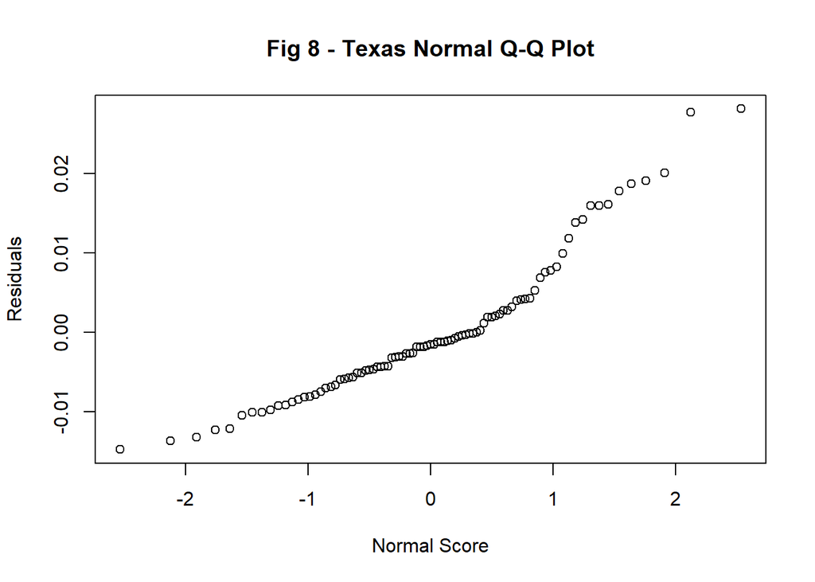

```r
qqnorm(residsTX,main="Fig 8 - Texas Normal Q-Q Plot",    # QQ Plot for CO residuals
       xlab="Normal Score",                              # add y-axis label
       ylab="Residuals")                                 # add x-axis label
```

#### 8. Assumptions for the CO Beer

1. We will assume the data are independent.
2. No patterns seen in the residuals plot so relationship of the data is linear.
3. The variance appears constant in the residuals plot.
4. The normal QQ plot show residuals are relatively normal.

#### Assumptions for the TX Beer

1. We will assume the data are independent.
2. No patterns seen in the residuals plot so relationship of the data is linear.
3. The variance appears constant in the residuals plot.
4. The normal QQ plot show residuals are relatively normal.

### D. Gain inference from the model

#### 9. Print parameter estimate table. Interpret slope. Is there evidence the relationship between TX & CO ABV vs IBU is significantly different?

#### COLORADO

```r
summary(fitCO)
```

```
##
## Call:
## lm(formula = AlcoholByVolume ~ BitternessUnits, data = beerCO)
##
## Residuals:
##       Min        1Q    Median        3Q       Max
## -0.018158 -0.007266 -0.003293  0.006453  0.032853
##
## Coefficients:
##                  Estimate Std. Error t value Pr(>|t|)
## (Intercept)     4.740e-02  1.856e-03   25.54   <2e-16 ***
## BitternessUnits 3.676e-04  3.432e-05   10.71   <2e-16 ***
## ---
## Signif. codes:  0 '***' 0.001 '**' 0.01 '*' 0.05 '.' 0.1 ' ' 1
##
## Residual standard error: 0.01077 on 144 degrees of freedom
## Multiple R-squared:  0.4433, Adjusted R-squared:  0.4395
## F-statistic: 114.7 on 1 and 144 DF,  p-value: < 2.2e-16
```

#### For every 1 IBU increase, the estimated ABV increases 3.676e-04 (~0.037%).

#### TEXAS

```r
summary(fitTX)
```

```
##
## Call:
## lm(formula = AlcoholByVolume ~ BitternessUnits, data = beerTX)
##
## Residuals:
##       Min        1Q    Median        3Q       Max
## -0.014764 -0.005738 -0.001560  0.003182  0.028096
##
## Coefficients:
##                  Estimate Std. Error t value Pr(>|t|)
## (Intercept)     4.347e-02  1.772e-03   24.54   <2e-16 ***
## BitternessUnits 4.172e-04  3.683e-05   11.33   <2e-16 ***
## ---
## Signif. codes:  0 '***' 0.001 '**' 0.01 '*' 0.05 '.' 0.1 ' ' 1
##
## Residual standard error: 0.009078 on 87 degrees of freedom
## Multiple R-squared:  0.596,  Adjusted R-squared:  0.5914
## F-statistic: 128.3 on 1 and 87 DF,  p-value: < 2.2e-16
```

#### For every 1 IBU increase, the estimated ABV increases 4.172e-04 (~0.042%).

#### There doesn’t appear to be any evidence supporting a significant difference with ABV vs IBU between Colorado and Texas.

#### 10. Confidence Intervals

#### COLORADO

```r
confint(fitCO,level=.95)
```

```
##                       2.5 %       97.5 %
## (Intercept)     0.043732505 0.0510700022
## BitternessUnits 0.000299726 0.0004354124
```

#### We are 95% confident for every 1 IBU increase, the ABV increase has a plausible range of 2.997e-04 to 4.354e-04 (~0.03% to 0.0435%).

#### TEXAS

```r
confint(fitTX,level=.95)
```

```
##                       2.5 %       97.5 %
## (Intercept)     0.039952379 0.0469949413
## BitternessUnits 0.000344007 0.0004903987
```

#### We are 95% confident for every 1 IBU increase, the ABV increase has a plausible range of 3.44e-04 to 4.904e-04 (~0.034% to 0.049%).

#### Since there is an overlap with the Colorado and Texas confidence intervals, there is not enought evidence supporting a significant diference with ABV vs IBU betweeen Colorado and Texas.

### E. Compare two competing models: External Cross Validation

#### 11. Add IBU squared colume to data

```r
beerCOTX <- within(beerCOTX, IBU2 <- beerCOTX$BitternessUnits*beerCOTX$BitternessUnits)
head(beerCOTX)
```

```
##      BreweryID                BreweryName           City State
## 462         67   Freetail Brewing Company    San Antonio    TX
## 754        129   Real Ale Brewing Company         Blanco    TX
## 1947       392       Breckenridge Brewery         Denver    CO
## 280         38      Avery Brewing Company        Boulder    CO
## 458         67   Freetail Brewing Company    San Antonio    TX
## 1124       188 Pedernales Brewing Company Fredericksburg    TX
##                   BeerName BeerID AlcoholByVolume BitternessUnits
## 462     Yo Soy Un Berliner   2520           0.044               5
## 754  18th Anniversary Gose   2370           0.044               5
## 1947           Agave Wheat   1522           0.042               9
## 280           White Rascal    108           0.056              10
## 458                Rye Wit   2522           0.042              10
## 1124             Lobo Lito   2238           0.040              12
##                    BeerStyle Ounces IBU2
## 462       Berliner Weissbier     12   25
## 754                     Gose     12   25
## 1947 American Pale Wheat Ale     12   81
## 280                  Witbier     12  100
## 458                  Witbier     12  100
## 1124             Light Lager     12  144
```

#### 12. For each state, create a training and test set from the data (60%/40% split respectively). Print a summary of each new data frame. There should be four: TrainingCO, TestCO, TrainingTX, TestTX.

```r
#Divide CO into training and test set into 60% training & 40% test
samplesizeCO=nrow(filter(beerCOTX,State=="CO"))
train_percent = .6
train_indicesCO = sample(seq(1,samplesizeCO,length = samplesizeCO),train_percent*samplesizeCO)
trainCO = subset(beerCOTX,beerCOTX$State=="CO")[train_indicesCO,] # CO random training data from original data
testCO = subset(beerCOTX,beerCOTX$State=="CO")[-train_indicesCO,] # CO random test data from original data
```

#### Summary for Colorado Training Set

```r
summary(trainCO)
```

```
##    BreweryID     BreweryName            City              State
##  Min.   : 38.0   Length:87          Length:87          Length:87
##  1st Qu.:120.0   Class :character   Class :character   Class :character
##  Median :221.0   Mode  :character   Mode  :character   Mode  :character
##  Mean   :263.1
##  3rd Qu.:419.0
##  Max.   :524.0
##
##                        BeerName      BeerID       AlcoholByVolume
##  Dale's Pale Ale           : 3   Min.   :   1.0   Min.   :0.04200
##  Fat Tire Amber Ale        : 2   1st Qu.: 596.5   1st Qu.:0.05300
##  Mama's Little Yella Pils  : 2   Median : 871.0   Median :0.06500
##  Modus Hoperandi           : 2   Mean   :1084.3   Mean   :0.06422
##  5:00 O'Clock Afternoon Ale: 1   3rd Qu.:1461.5   3rd Qu.:0.07050
##  American India Red Ale    : 1   Max.   :2563.0   Max.   :0.09500
##  (Other)                   :76
##  BitternessUnits                           BeerStyle      Ounces
##  Min.   : 14.00   American Pale Ale (APA)       :16   Min.   :12.00
##  1st Qu.: 24.50   American IPA                  :13   1st Qu.:12.00
##  Median : 40.00   American Amber / Red Ale      : 6   Median :12.00
##  Mean   : 45.32   American Double / Imperial IPA: 6   Mean   :13.26
##  3rd Qu.: 65.00   Kölsch                        : 4   3rd Qu.:16.00
##  Max.   :104.00   American Pale Lager           : 3   Max.   :19.20
##                   (Other)                       :39
##       IBU2
##  Min.   :  196.0
##  1st Qu.:  600.5
##  Median : 1600.0
##  Mean   : 2601.3
##  3rd Qu.: 4225.0
##  Max.   :10816.0
##
```

#### Summary for Colorado Test Set

```r
summary(testCO)
```

```
##    BreweryID     BreweryName            City              State
##  Min.   :  7.0   Length:59          Length:59          Length:59
##  1st Qu.: 95.5   Class :character   Class :character   Class :character
##  Median :167.0   Mode  :character   Mode  :character   Mode  :character
##  Mean   :224.3
##  3rd Qu.:399.0
##  Max.   :521.0
##
##                 BeerName      BeerID     AlcoholByVolume
##  Shift              : 2   Min.   :   4   Min.   :0.04200
##  1554 Black Lager   : 1   1st Qu.: 511   1st Qu.:0.05300
##  Agave Wheat        : 1   Median : 880   Median :0.06500
##  American Red Saison: 1   Mean   :1072   Mean   :0.06575
##  Apricot Blonde     : 1   3rd Qu.:1614   3rd Qu.:0.07250
##  Avalanche Ale      : 1   Max.   :2644   Max.   :0.09900
##  (Other)            :52
##  BitternessUnits                           BeerStyle      Ounces
##  Min.   :  9.00   American IPA                  :10   Min.   :12.00
##  1st Qu.: 24.50   American Pale Ale (APA)       : 9   1st Qu.:12.00
##  Median : 40.00   American Double / Imperial IPA: 5   Median :12.00
##  Mean   : 50.54   Russian Imperial Stout        : 5   Mean   :12.98
##  3rd Qu.: 71.00   American Amber / Red Ale      : 4   3rd Qu.:12.00
##  Max.   :100.00   American Pale Lager           : 2   Max.   :19.20
##                   (Other)                       :24
##       IBU2
##  Min.   :   81.0
##  1st Qu.:  600.5
##  Median : 1600.0
##  Mean   : 3400.6
##  3rd Qu.: 5042.0
##  Max.   :10000.0
##
```

```r
#Divide TX into training and test set into 60% training & 40% test
samplesizeTX=nrow(filter(beerCOTX,State=="TX"))
train_percent = .6
train_indicesTX = sample(seq(1,samplesizeTX,length = samplesizeTX),train_percent*samplesizeTX)
trainTX = subset(beerCOTX,beerCOTX$State=="TX")[train_indicesTX,] # TX random training data from original data
testTX = subset(beerCOTX,beerCOTX$State=="TX")[-train_indicesTX,] # TX random test data from original data
```

#### Summary for Texas Training Set

```r
summary(trainTX)
```

```
##    BreweryID     BreweryName            City              State
##  Min.   : 30.0   Length:53          Length:53          Length:53
##  1st Qu.:119.0   Class :character   Class :character   Class :character
##  Median :129.0   Mode  :character   Mode  :character   Mode  :character
##  Mean   :166.3
##  3rd Qu.:214.0
##  Max.   :427.0
##
##                       BeerName      BeerID     AlcoholByVolume
##  1836                     : 1   Min.   :  44   Min.   :0.04000
##  Alteration               : 1   1st Qu.:1091   1st Qu.:0.05000
##  Barn Burner Saison       : 1   Median :2042   Median :0.05500
##  Bat Outta Helles         : 1   Mean   :1723   Mean   :0.06006
##  Battle LIne              : 1   3rd Qu.:2211   3rd Qu.:0.06600
##  Block Party Robust Porter: 1   Max.   :2588   Max.   :0.09900
##  (Other)                  :47
##  BitternessUnits                           BeerStyle      Ounces
##  Min.   : 10.00   American Blonde Ale           : 7   Min.   :12.00
##  1st Qu.: 21.00   American Double / Imperial IPA: 5   1st Qu.:12.00
##  Median : 33.00   American IPA                  : 5   Median :12.00
##  Mean   : 40.55   American Pale Ale (APA)       : 4   Mean   :12.53
##  3rd Qu.: 50.00   Witbier                       : 4   3rd Qu.:12.00
##  Max.   :110.00   American Brown Ale            : 3   Max.   :16.00
##                   (Other)                       :25
##       IBU2
##  Min.   :  100
##  1st Qu.:  441
##  Median : 1089
##  Mean   : 2290
##  3rd Qu.: 2500
##  Max.   :12100
##
```

#### Summary for Texas Test Set

```r
summary(testTX)
```

```
##    BreweryID     BreweryName            City              State
##  Min.   : 30.0   Length:36          Length:36          Length:36
##  1st Qu.:124.2   Class :character   Class :character   Class :character
##  Median :127.5   Mode  :character   Mode  :character   Mode  :character
##  Mean   :149.9
##  3rd Qu.:192.5
##  Max.   :427.0
##
##                   BeerName      BeerID     AlcoholByVolume
##  18th Anniversary Gose: 1   Min.   : 464   Min.   :0.04400
##  BLAKKR               : 1   1st Qu.:1227   1st Qu.:0.05075
##  Bombshell Blonde     : 1   Median :2006   Median :0.05500
##  Broken Bridge        : 1   Mean   :1749   Mean   :0.06072
##  Brutus               : 1   3rd Qu.:2216   3rd Qu.:0.07000
##  Chupahopra           : 1   Max.   :2600   Max.   :0.09900
##  (Other)              :30
##  BitternessUnits                           BeerStyle      Ounces
##  Min.   :  5.00   American Pale Ale (APA)       : 5   Min.   :12.00
##  1st Qu.: 20.00   American IPA                  : 4   1st Qu.:12.00
##  Median : 30.00   American Double / Imperial IPA: 3   Median :12.00
##  Mean   : 40.17   American Amber / Red Ale      : 2   Mean   :13.22
##  3rd Qu.: 60.75   American Blonde Ale           : 2   3rd Qu.:16.00
##  Max.   :118.00   Dunkelweizen                  : 2   Max.   :16.00
##                   (Other)                       :18
##       IBU2
##  Min.   :   25
##  1st Qu.:  400
##  Median :  925
##  Mean   : 2350
##  3rd Qu.: 3692
##  Max.   :13924
##
```

#### 13. Compare Linear and Quadratic Models

#### Models fit for CO

```r
#Fit the linear model for cO
fitTrainCO1 = lm(AlcoholByVolume~BitternessUnits, data = trainCO) # get the beta hats
predsTrainCO1 = predict(fitTrainCO1)                  # Model predictions on training data which was used to fit the model
predsTestCO1 = predict(fitTrainCO1, newdata = testCO) # Model predictions using test data

#Fit the quadratic model for cO
fitTrainCO2 = lm(AlcoholByVolume~BitternessUnits + IBU2, data = trainCO) # get the beta hats
predsTrainCO2 = predict(fitTrainCO2)                  # Model predictions on training data which was used to fit the model
predsTestCO2 = predict(fitTrainCO2, newdata = testCO) # Model predictions using test data
```

#### Calculate the CO MSEs

```r
MSEholderTestCO1 = sum((predsTestCO1 - testCO$AlcoholByVolume)^2)/(length(testCO$AlcoholByVolume) - 2)     # MSE Test, linear
MSEholderTestCO2 = sum((predsTestCO2 - testCO$AlcoholByVolume)^2)/(length(testCO$AlcoholByVolume) - 2)     # MSE Test, quadratic
```

#### CO Model Comparison Results

```
## [1] "Colorado MSE for the Linear Model Test Data = 0.000147974768896928"
```

```
## [1] "Colorado MSE for the Quadratic Model Test Data = 0.000143838824503225"
```

#### Since the MSE for the linear model is greater than the MSE Delta for the quadratic model, the quadratic model is better than the linear model for Colorado AVB vs IBU. The difference is very small. The next step might be to check if this difference is significant.

#### Models fit for TX

```r
#Fit the linear model for TX
fitTrainTX1 = lm(AlcoholByVolume~BitternessUnits, data = trainTX) # get the beta hats
predsTrainTX1 = predict(fitTrainTX1)                  # Model predictions on training data which was used to fit the model
predsTestTX1 = predict(fitTrainTX1, newdata = testTX) # Model predictions using test data

#Fit the quadratic model for cO
fitTrainTX2 = lm(AlcoholByVolume~BitternessUnits + IBU2, data = trainTX) # get the beta hats
predsTrainTX2 = predict(fitTrainTX2)                  # Model predictions on training data which was used to fit the model
predsTestTX2 = predict(fitTrainTX2, newdata = testTX) # Model predictions using test data
```

#### Calculate the TX MSEs

```r
MSEholderTestTX1 = sum((predsTestTX1 - testTX$AlcoholByVolume)^2)/(length(testTX$AlcoholByVolume) - 2)     # MSE Test, linear
MSEholderTestTX2 = sum((predsTestTX2 - testTX$AlcoholByVolume)^2)/(length(testTX$AlcoholByVolume) - 2)     # MSE Test, quadratic
```

#### TX Model Comparison Results

```
## [1] "MSE for the Linear Model Test Data = 9.27607423190502e-05"
```

```
## [1] "MSE for the Quadratic Model Test Data = 9.19665692590266e-05"
```

#### Since the MSE for the linear model is greater than the MSE Delta for the quadratic model, the quadratic model is better than the linear model for Texas AVB vs IBU. The difference is very small. The next step might be to check if this difference is significant.

#### Github Location: https://github.com/stevebramhall/DoingDataScience/tree/master/HW9